# Things I want to remember

# Enriching a vector

Sometimes I have a vector of things that I want to do some enrichment of everything in that vector and get the results as a `data.frame`. Here are a couple approaches to make that happen.

```r
myList <- c("Kevin","Bob","Gabe","Jay","Suzanne","Marc","Dave","Bhaskar")
enriched <- ldply(myList, function(x){c(x,tolower(x),nchar(x))})
enriched %>% head()
```

```
##        V1      V2 V3
## 1   Kevin   kevin  5
## 2     Bob     bob  3
## 3    Gabe    gabe  4
## 4     Jay     jay  3
## 5 Suzanne suzanne  7
## 6    Marc    marc  4
```

That works, but it also requires you to use plyr which we would like to avoid because of the namespace collisions with dplyr. So here’s a way to do it using data.table. Bob Rudis says this will be fast and use less memory also.

```r
enriched <- rbindlist(lapply(myList, function(x) {data.frame(x, tolower(x), nchar(x))}))
enriched %>% head()
```

```
##          x tolower.x. nchar.x.
## 1:   Kevin      kevin        5
## 2:     Bob        bob        3
## 3:    Gabe       gabe        4
## 4:     Jay        jay        3
## 5: Suzanne    suzanne        7
## 6:    Marc       marc        4
```

# Grouping and aggregation

Let’s say we have a data table of observations over mutiple states and we would like to get a summary of each state. This is a split, apply, combine problem that we’ve seen dozens of times. But `dplyr` makes it really easy with the `group_by` function. `Group_by` doesn’t seem to change the look of the data, but it makes it so that all of the summary functions you run on the data will apply to the individual groups rather than the whole table.

```r
polling %>% head()
```

```
##     state  answer
## 1      CA     Yes
## 2      FL Unknown
## 3      MN Unknown
## 4      MN Unknown
## 5      MN Unknown
## 6 Unknown Unknown
```

```r
polling %>%
  arrange(state, answer) %>% # sorts the frame. Unnecessary but nice to look at
  group_by(state) %>% # invisible grouping of each state
  mutate(n=n()) %>%  # adds a count of how man instances of that state were seen
  ungroup %>%  # remove the invisible grouping
  group_by(state, answer) %>%  # invisible grouping of each combination of state and answer
  mutate(n1=n(), pct=n1/n) %>%  # adds a count of how many instances of that state/answer combo were seen
  distinct %>% # remove the duplicates
  head # don't show everything
```

```
## Source: local data frame [6 x 5]
## Groups: state, answer
##
##   state  answer   n  n1       pct
## 1    CA      No 397  65 0.1637280
## 2    CA Unknown 397 242 0.6095718
## 3    CA     Yes 397  90 0.2267003
## 4    FL      No 191  29 0.1518325
## 5    FL Unknown 191 110 0.5759162
## 6    FL     Yes 191  52 0.2722513
```

# adding and reshaping

To get a count of fall the true values in several columns you can use the built-in `colSums()`. However that returns a list so you can use `data.frame(colSums(x))` to get it back to a dataframe. But, then you’ve got values where you used to have row names.

```r
moveit <- data.frame(matrix(runif(200) > .6, ncol=10))
moveit <- data.frame(colSums(moveit))
moveit$variable <- rownames(moveit)
rownames(moveit) <- NULL
```

Sometimes I have data in two columns and I want to be able to plot it. ggplot wants this to be long data which we can convert using tidyr. Think about `gather()` like this: create a new dataframe with a column called “first name” and a column called “second name” but dont include “third name” in the calculation.

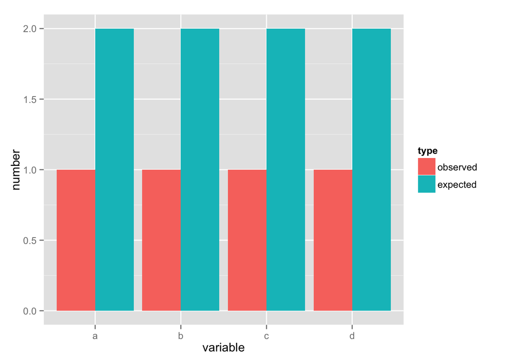

```r
moveit <- data.frame(variable=c("a","b","c","d"), observed=c(1,1,1,1), expected=c(2,2,2,2))
moveit <- moveit %>% gather(type, number, -variable)

plt <- ggplot(moveit, aes(x=variable, y=number)) + geom_bar(stat="identity", position="dodge", aes(fill=type))
print(plt)
```